# Hoofprint: Minnesota State Agricultural Land Use

**Minnesota’s Agricultural Land Use**

Agricultural land use plays a central role in shaping Minnesota’s nearly 51-million-acre landscape. Roughly half of the state’s land (approximately 25.4 million acres) is actively managed for agricultural production, with cropland forming the dominant component of land in farms at 21.5 million acres.

This cropland is highly concentrated on a small number of major crops. Corn and soybeans together account for the majority of cropland, with approximately 7.7 million acres planted to corn and 7.6 million acres to soybeans in 2022. These crops serve multiple end uses, including livestock feed, industrial processing, and biofuels, but are closely linked to animal agriculture through feed systems, particularly via corn grain, silage, and soybean meal.

At the same time, Minnesota supports a large and diversified livestock sector. In 2022, the state had approximately 8.9 million hogs and pigs, 2.1 million cows, and significant poultry inventories, including 14.9 million turkeys and over 14.5 million laying hens. These livestock systems create sustained demand for feed crops.

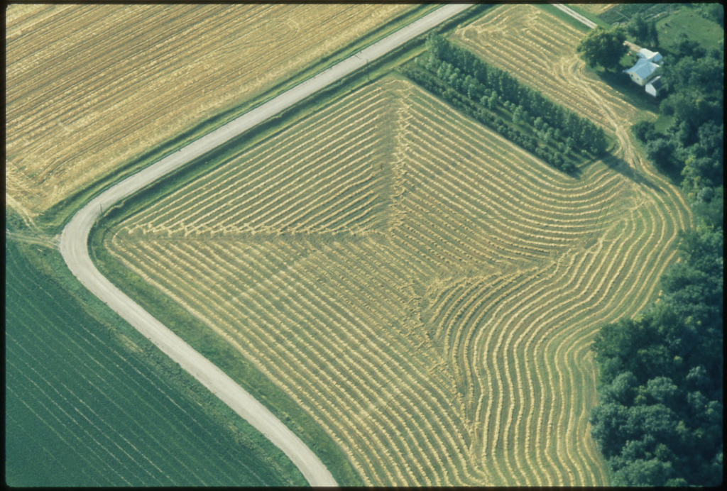

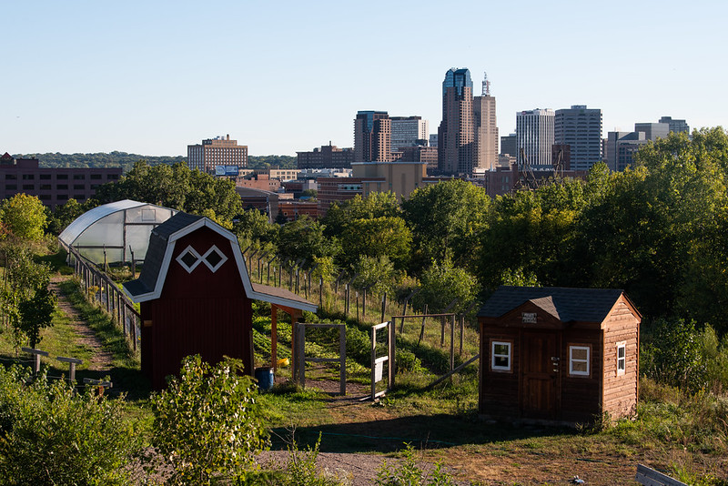

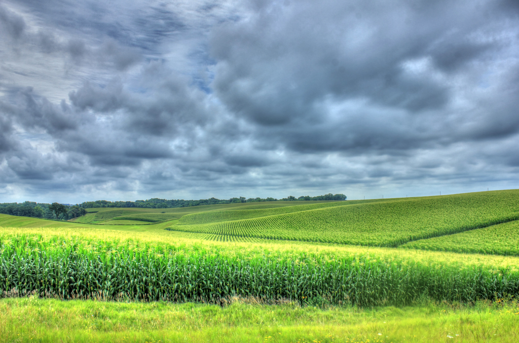

Over the study period, Minnesota’s farm structure shifted toward fewer and larger operations. The number of farm operations fell from 80,839 in 2002 and a near-identical 80,992 in 2007 to 65,531 in 2022, a decline of about 19%.

Average farm size moved in the opposite direction, dipping from 340 acres in 2002 to 332 in 2007 before rising steadily to 388 acres in 2022.

Total land in farms contracted more modestly, from about 26.9 million to 25.4 million acres, indicating that production is becoming concentrated on fewer, larger operations. These trends are illustrated in Figures 1 through 4 below.

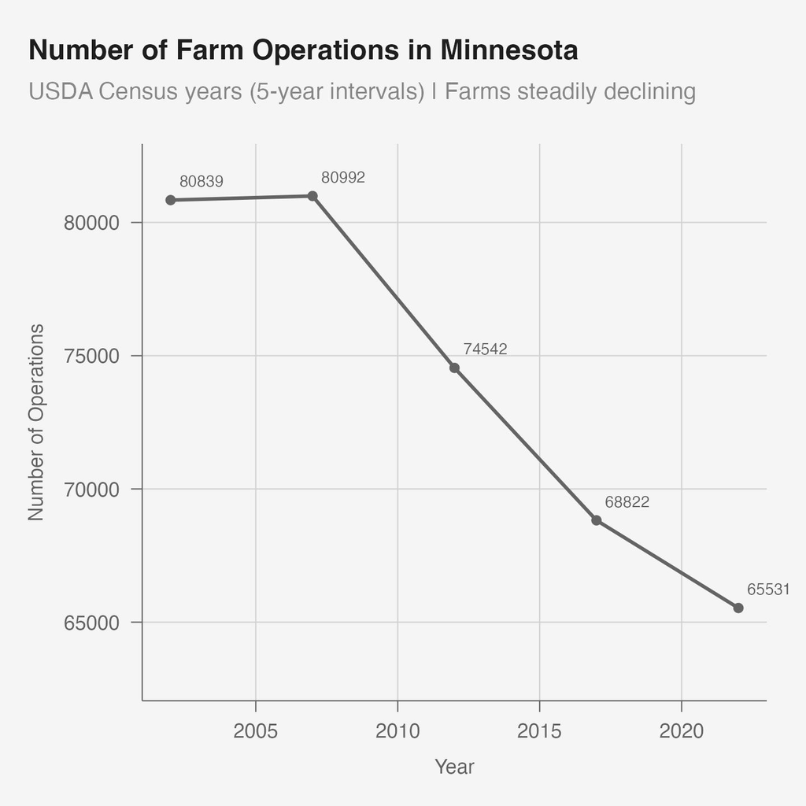

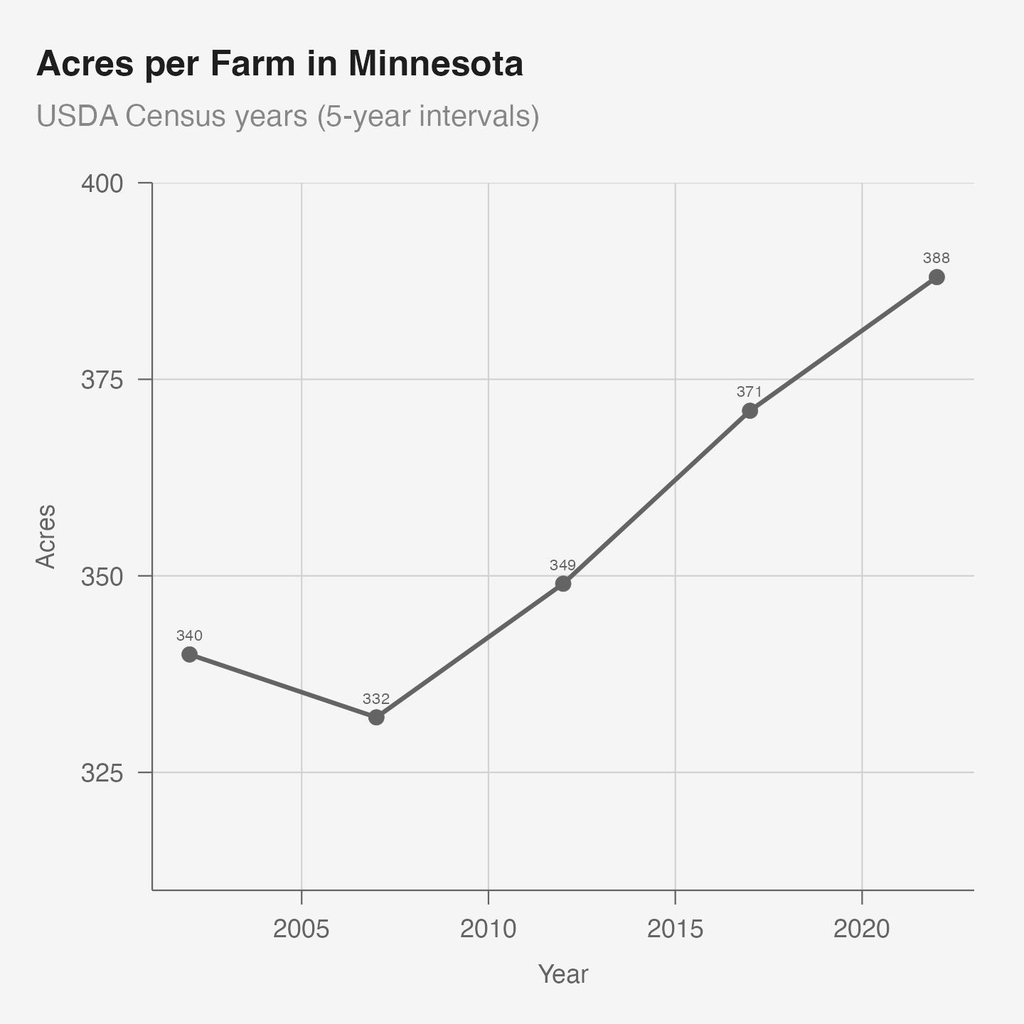

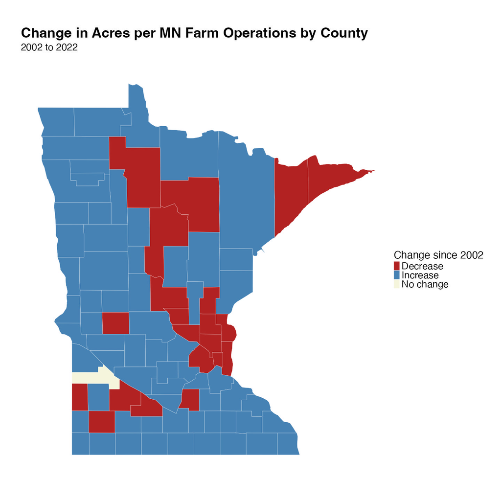

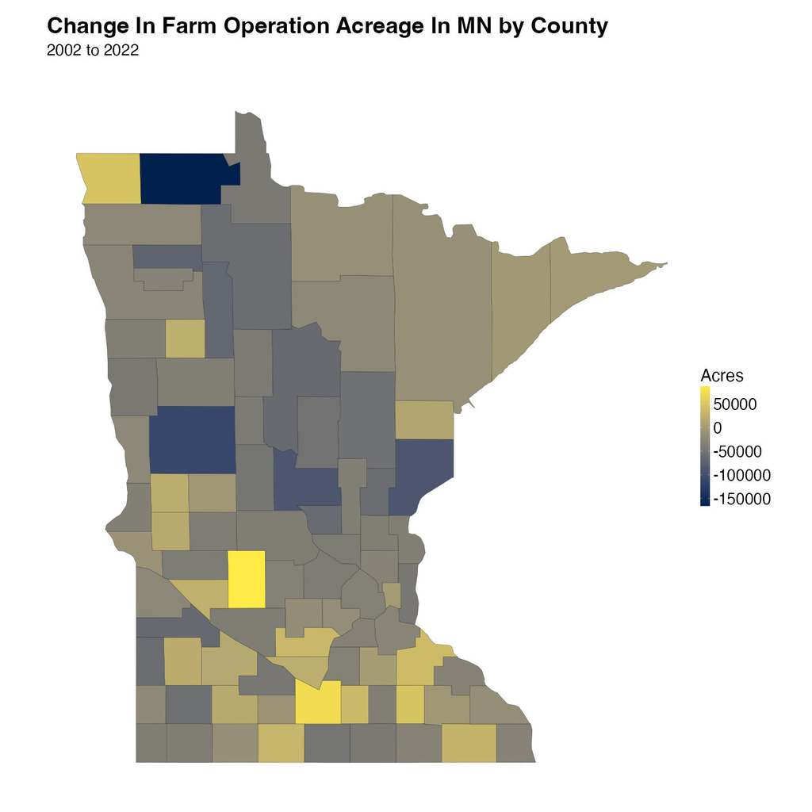

Hoofprint makes the relationship between land use and livestock systems visible. By distinguishing land devoted to feed crops, grazing, and other agricultural uses, the analysis identifies that approximately 16.8 million acres, about 33% of Minnesota’s total land base and roughly 64% of its agricultural land, is functionally linked to animal agriculture. This includes pastureland as well as cropland producing feed inputs that support livestock production.

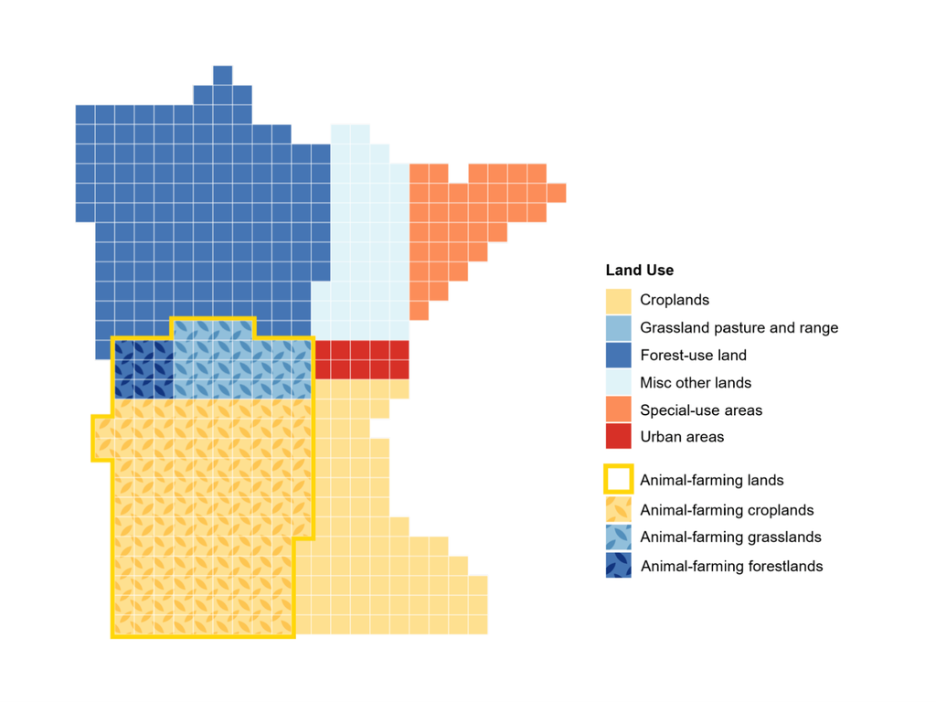

**Objective and Scope**

The objective of this state report is to map and analyze land use in a way that highlights how much of Minnesota land is devoted to agricultural production, and within that, how much is functionally linked to livestock systems through feed cropping and grazing.

Unlike traditional land-use representations that emphasize broad categories such as urbanization or forest cover, this analysis focuses specifically on the agricultural landscape and its internal composition. In particular, this study distinguishes between cropland used for feed production, cropland used for human food and other purposes, and land used for pasture and grazing.

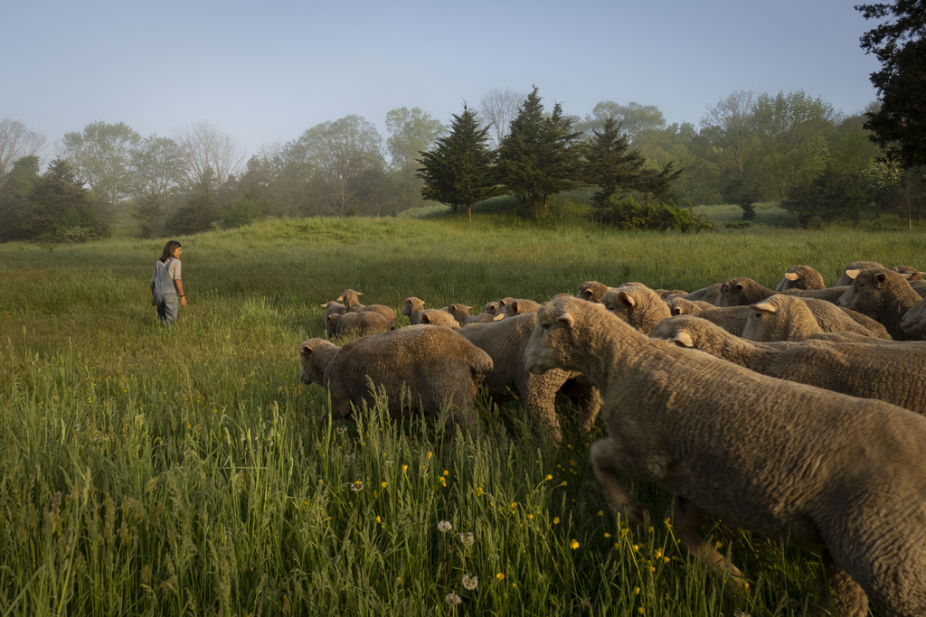

The analysis is guided by the following core questions:

- How much of Minnesota’s land area is devoted to agricultural uses, particularly cropland and grazing land?
- Within agricultural land, how much is used to support livestock systems through feed crops and pasture?
- How do patterns of crop production relate to the spatial distribution of livestock, particularly in relation to feed demand?

**Findings**

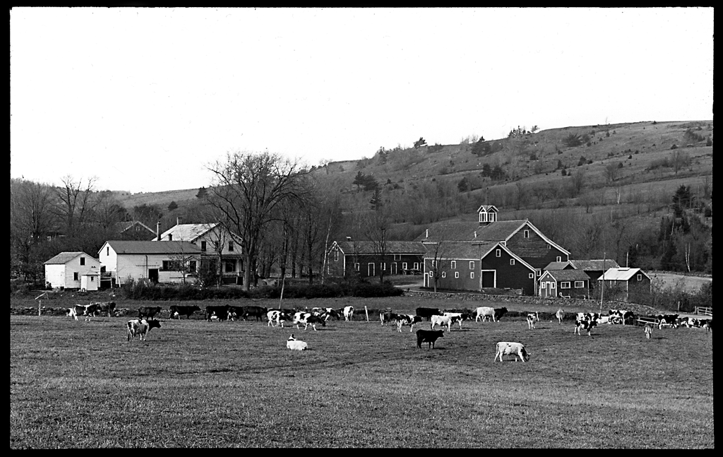

*Quantitative Land Use Breakdown*

Minnesota’s land base is dominated by cropland and forest land, with smaller shares of grassland pasture, developed land, and other uses. Cropland alone accounts for approximately 21.5 million acres, making it the single largest actively managed land category within the state.

The following maps use a simplified, proportional visualization approach to show how land is allocated across major categories such as forest, cropland, grassland, and urban land.

Each colored square (“tile”) represents approximately 110,000 acres of land.

The total number of tiles in each category matches official statewid acreage totals from the U.S. Department of Agriculture’s Major Uses of Land (MLU) Statistics.

The maps are designed to communicate relative land shares clearly, not to depict exact field boundaries, parcel locations, or farm ownership. The apatial arrangement of tiles preserves the general outline of Minnesota and broad geographic coherence, but individual tiles should not be interpreted as showing precise land-use locations.

The map highlighting land associated with animal agriculture groups together tiles representing feed cropland and grazing land into a single, contiguous region for visual clarity.

This region does not show the actual locations of livestock farms. Instead it represents the proportional amount of land used to support livestock production, based on feed and grazing acreage totals.

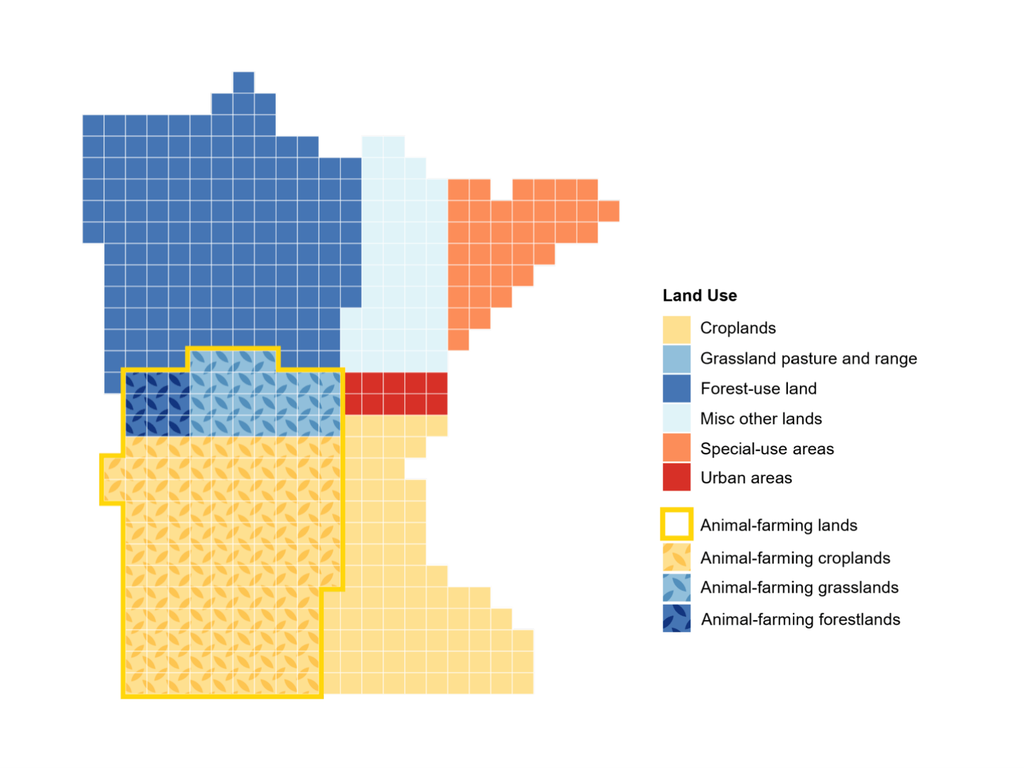

[figure not shown]

*Agriculture Dominates Actively Managed Land*

*Agricultural Land Linked to Livestock Systems*

Within cropland, a substantial share is functionally linked to animal agriculture through feed production. Applying the feed-allocation method to Minnesota’s crops, approximately 12.1 million acres of cropland, or about 61% of cropland used for crops, is used for feed and forage purposes. The figure to the right illustrates the proportional share of Minnesota’s land area associated with animal agriculture.

In addition to cropland, grazing-related land contributes to land use by livestock systems. This includes permanent pasture, grassland used for grazing, as well as smaller areas of cropland, and forest land used for grazing. These categories together account for approximately 4.6 million acres of grazing-related land, as reported in the USDA ERS Major Land Uses series.

Together, feed-allocated cropland of about 12.1 million acres and grazing-related land of about 4.6 million acres mean that approximately 16.8 million acres, about 33% of Minnesota’s total land base and roughly 64% of its agricultural land, is functionally linked to animal agriculture.

*Feed and Forage Crops Are Central*

Corn and soybeans define Minnesota’s agricultural production system and underpin both feed and industrial demand. They occupy over 15 million acres, making them the dominant crops across the state. Grain corn accounts for approximately 95% of harvested corn acreage, and silage corn accounts for 5%.

[figure not shown]

In 2022, approximately 7.7 million acres were planted with corn, 7.6 million acres with soybeans, and 1.4 million acres with hay and forage crops. Forage crops, including hay and alfalfa, are treated as fully dedicated to livestock feed. Corn silage also functions as a primary feed input, particularly for cattle. Even where crops are classified as mixed-use, such as corn grain and soybeans, a majority portion of production is used for livestock feed.

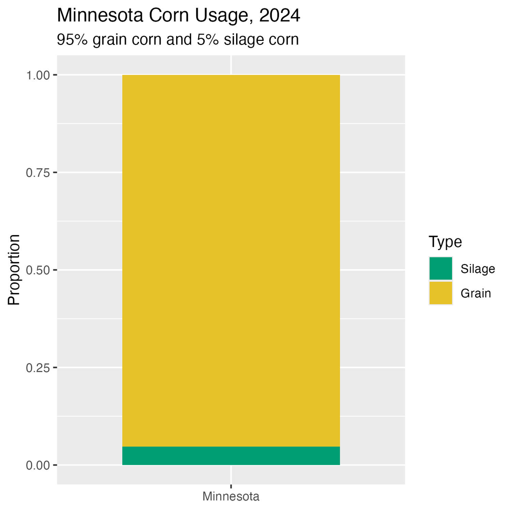

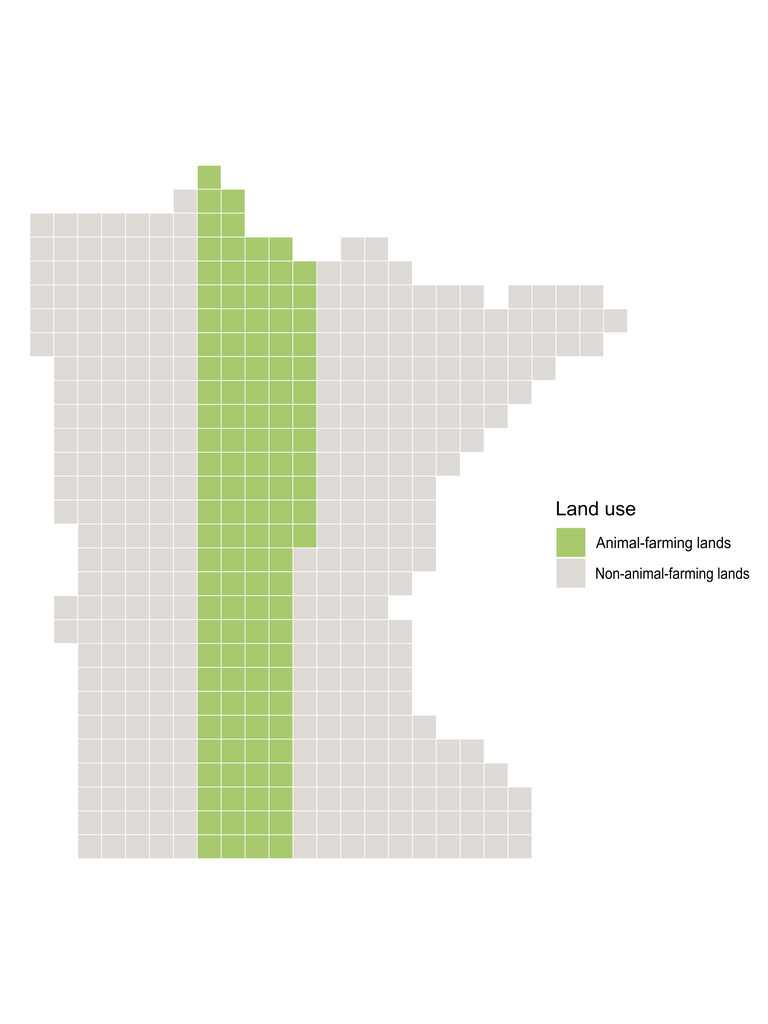

Corn serves multiple end uses. In addition to its role in livestock feed, a significant portion is directed toward ethanol. State-level data indicates that 34% of Minnesota corn is allocated to ethanol production.

For the purposes of this study, we rely on national figures instead. USDA ERS country-wide data on feed and residual use accounts for approximately 45% of domestically used corn, and DDGS return a further share to livestock rations.

This creates a feedback loop in which corn supports both energy production and animal agriculture. Crediting the domestically fed portion of distillers grains provides a corn feed share of approximately 54%. This total feed share of corn grain is counted toward the animal-linked footprint in the state.

[figure not shown]

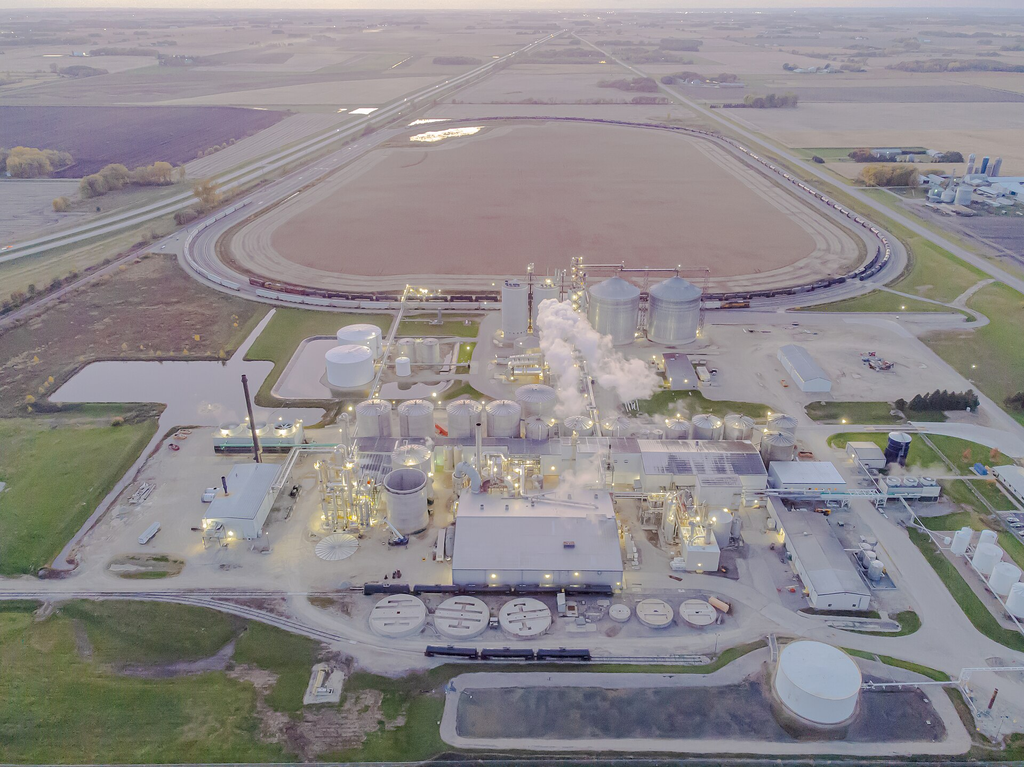

Most of the soybean output is crushed into soybean meal and oil, with the meal used extensively in livestock rations. Soybean use in biodiesel processing represents an additional end use that, while smaller than feed and food applications, has fluctuated in recent years.

Minnesota processed approximately 20.7 million bushels of soybeans for biodiesel in 2022, declining to approximately 18.4 million bushels by 2024.

At approximately 5-6% of Minnesota’s total soybean output, biodiesel represents a minority end use, with the substantial majority of soybean production continuing to flow into soybean meal for livestock rations.

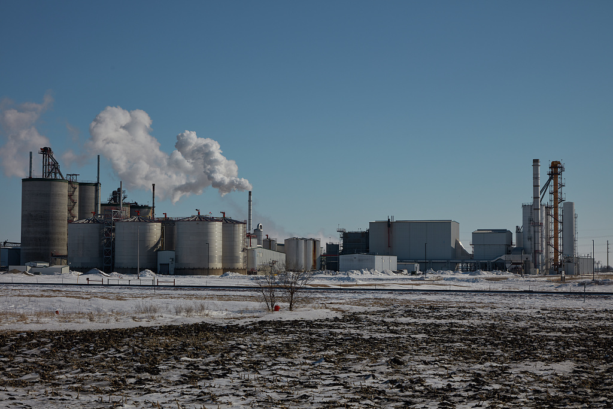

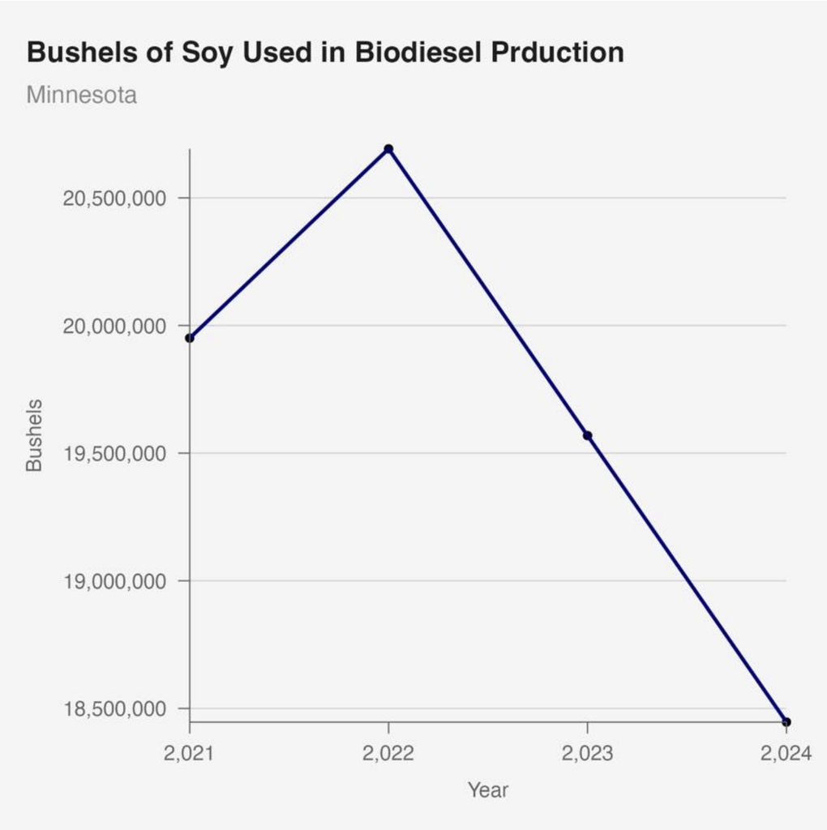

*Livestock Systems and Feed Demand*

*Livestock Systems and Feed Demand*

Dairy cows account for approximately 56% and beef cows for 44% of the state’s cows.

The composition of agricultural sales reflects this structure. It is a major economic and land-structuring component of the farm system. In 2022, about 60% of Minnesota’s agricultural sales came from crops and 40% from livestock, poultry, and related products.

Within the livestock category, hogs and pigs were the largest source of sales at approximately $4.67 billion, followed by milk from cows at about $2.51 billion, cattle and calves at roughly $2.09 billion, and poultry and eggs at about $1.94 billion.

Minnesota’s livestock system is commodity-intensive, with especially large swine and poultry sectors alongside cattle and dairy, which is reflected in its feed demand being driven by grain and oilseed crops as much as by forage.

Minnesota’s livestock sector is large and diversified, and its scale helps explain why feed demand is such a central feature of the state’s agricultural land use.

In 2022, Minnesota had approximately 8.87 million hogs and pigs, 2.12 million cattle and calves, 14.93 million turkeys, 14.55 million layers, and 7.77 million broilers and other meat-type chickens.

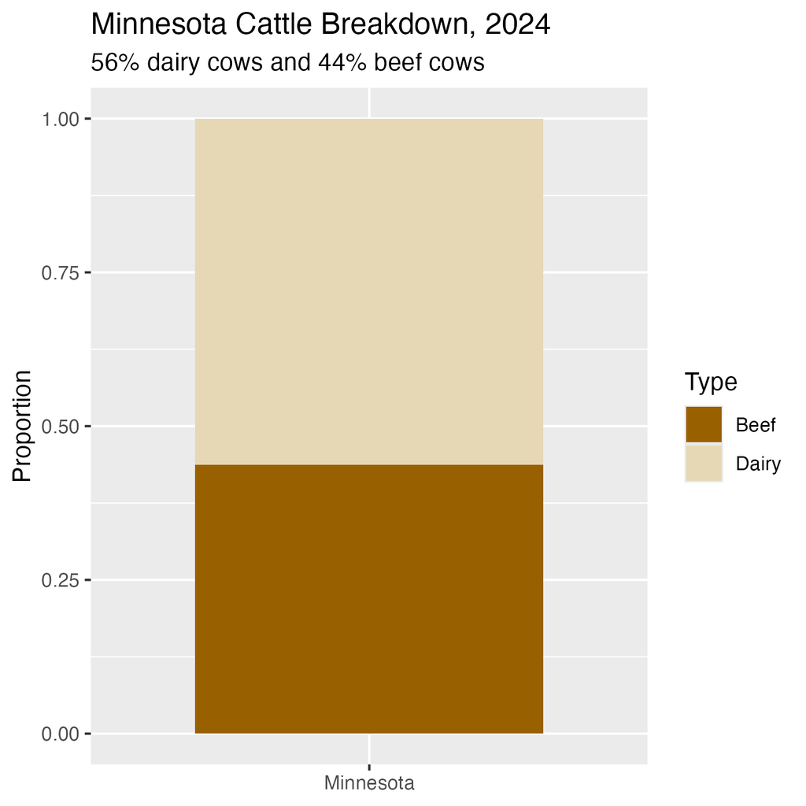

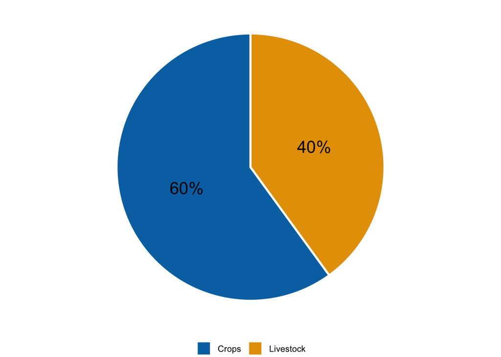

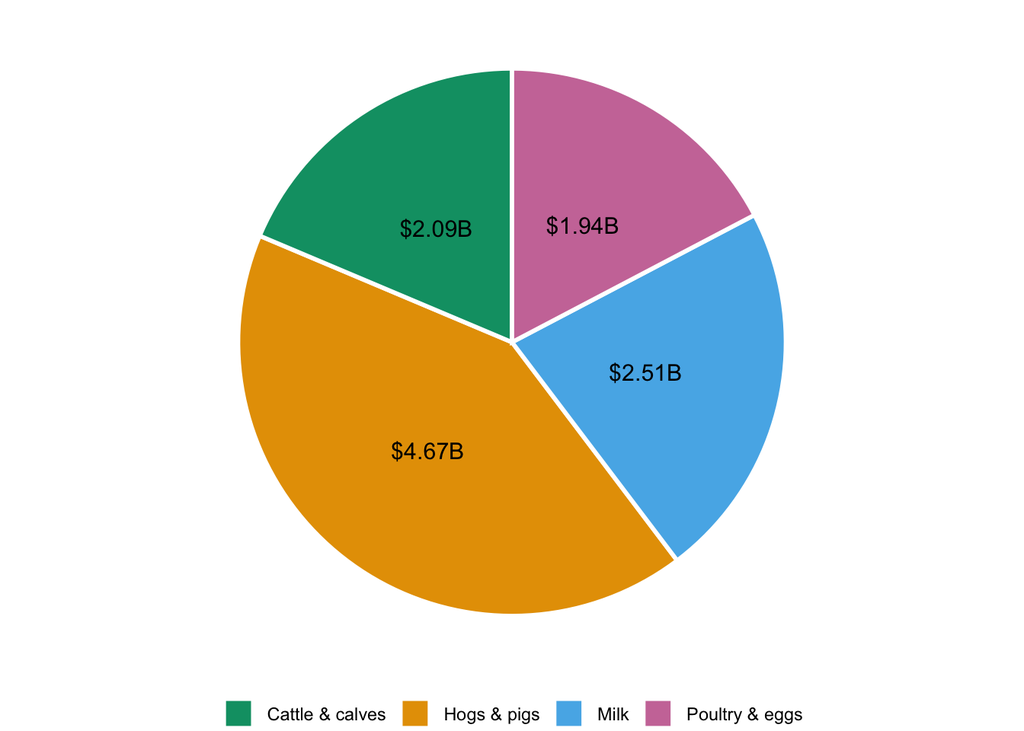

*Crop-Livestock Relationships*

Minnesota’s crop-livestock geography involves multiple feed systems operating across a diversified livestock sector. Hogs and pigs, the largest single contributor to Minnesota’s livestock sales at approximately $4.67 billion in 2022, depend primarily on corn grain and soybean meal delivered through commodity markets.

However, the analysis in this section focuses on the dairy-silage relationship as county-level data is available for dairy cows rather than hogs and pigs, which is difficult to isolate at a county-level since they are influenced by more distributed market mechanisms that do not correspond to administrative county boundaries.

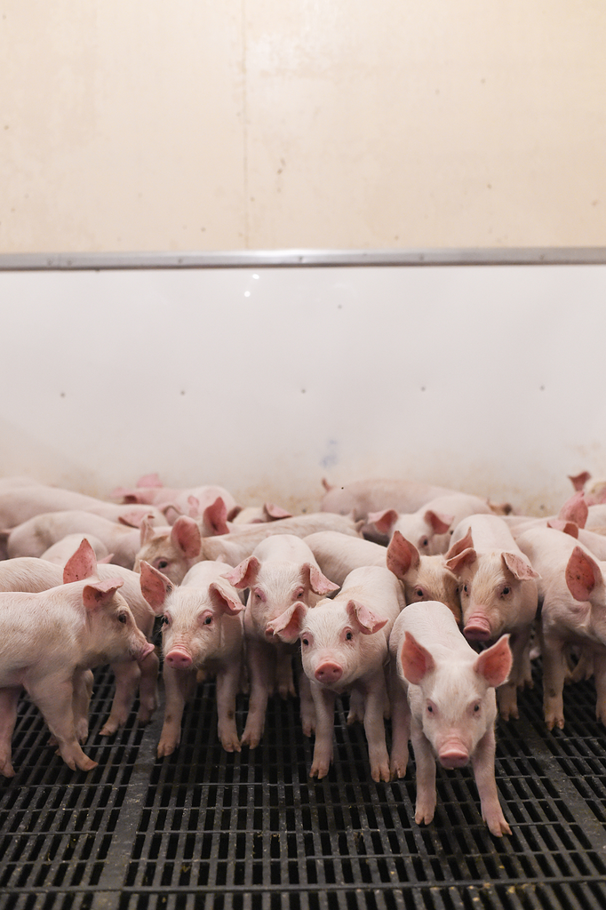

County-level regression shows a statistically significant relationship between dairy cow inventories and corn silage acreage, with roughly 0.58 additional acres of silage harvested per additional dairy cow. This indicates a tight linkage between dairy production and feed cropping at the county level.

*Land Use Trends and Structural Change*

The number of farms declined from 80,992 in 2007 to 65,531 in 2022, while average farm size increased from roughly 332 acres to 388 acres over the same period. At the same time, total farmland declined more modestly, from approximately 26.9 million acres to 25.4 million acres.

This divergence indicates that agricultural production is becoming more concentrated on fewer, larger operations. The increase in farm size alongside relatively stable land in farms suggests intensification rather than expansion, with production increasingly organized around large-scale crop and livestock systems.

The persistence of large livestock inventories alongside declining pasture suggests that livestock production is increasingly supported by cropland-based feed systems rather than grazing.

The combination of declining farm numbers, increasing farm size, and stable cropland indicates rising pressure on agricultural land to sustain production. With over 21 million acres of cropland supporting both feed and commodity markets, the system is increasingly dependent on high-output, row-crop production. At the same time, reductions in pasture and modest declines in total farmland suggest that land is being reallocated within agriculture.

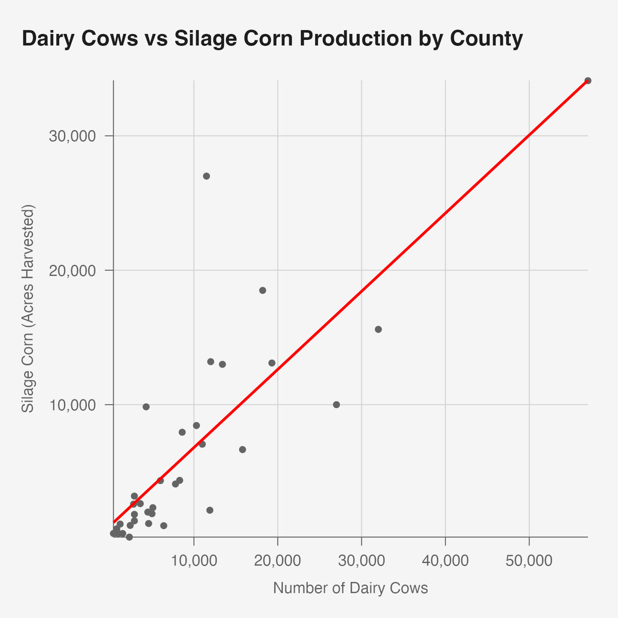

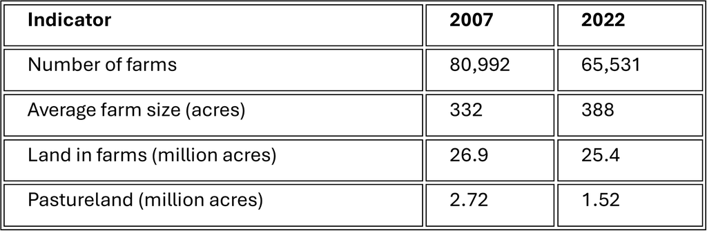

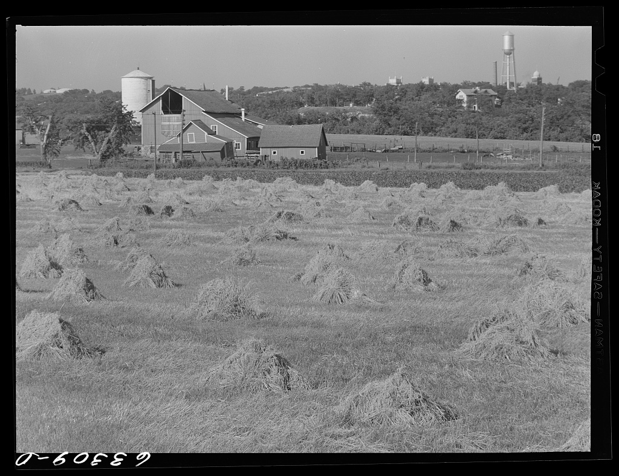

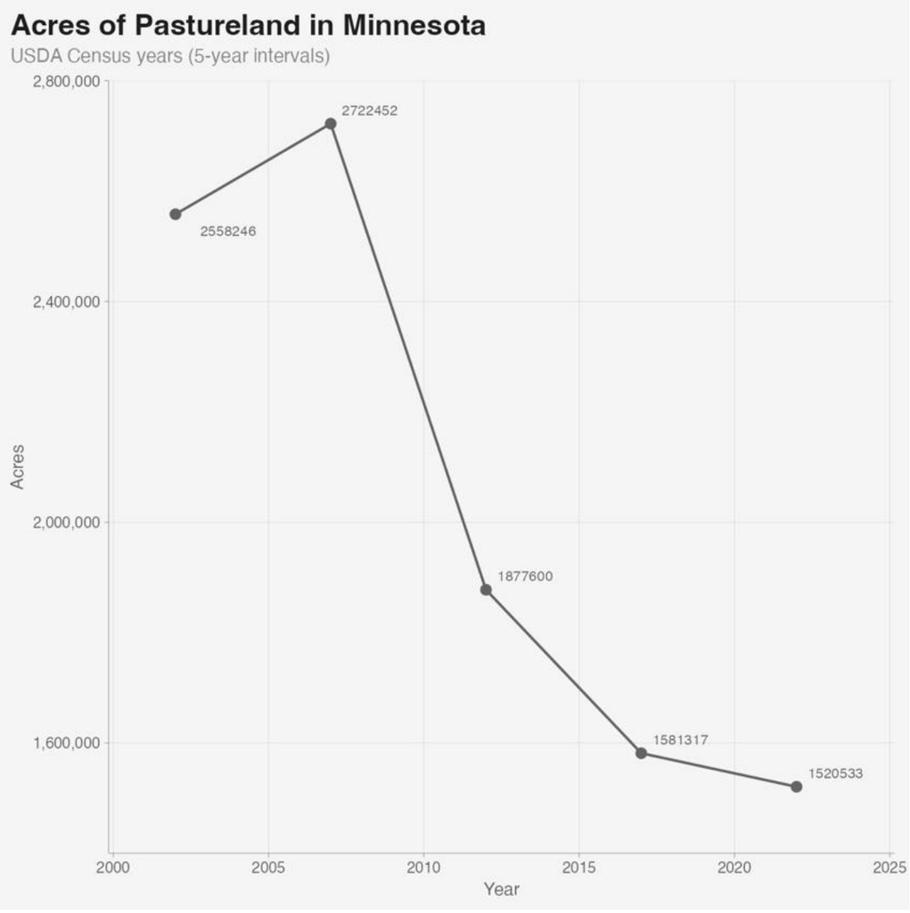

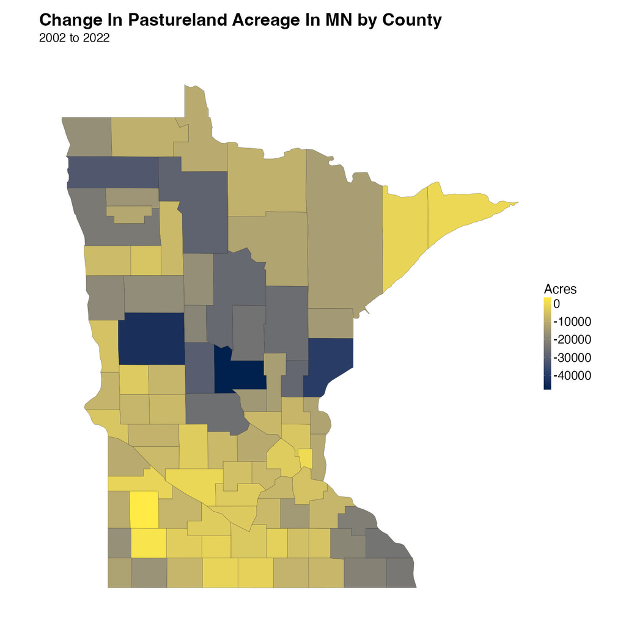

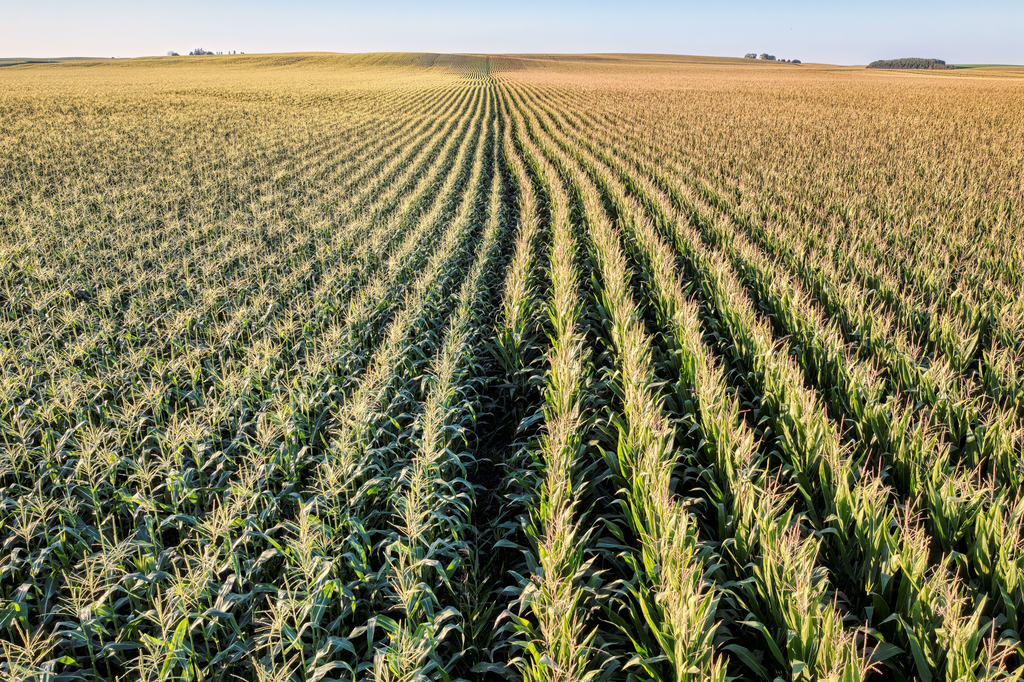

*Carbon Opportunity Costs of Feed Cropland*

*Climate Impacts of Land-Intensive Livestock Systems*

Land allocated to feed crops represents foregone opportunities for carbon sequestration that are particularly significant in the context of Minnesota’s ecological history. Based on the feed allocation method, approximately 12.1 million acres of Minnesota’s cropland, about 61% of the total, are in feed and forage use supporting livestock production directly or indirectly. A substantial portion of this land was historically prairie or wetland, particularly across the western and southwestern regions of the state where Minnesota’s prairie zone represents one of the most carbon-dense grassland and wetland landscapes in the upper Midwest. The recorded decline of approximately 1.2 million acres of pastureland between 2007 and 2022 provides a recent, measurable instance of this conversion dynamic, representing land that was functioning as grassland habitat and carbon sink before entering feed crop production. While this report does not model carbon outcomes directly, Minnesota’s combination of feed-linked cropland scale and ecological conversion history identifies the state as a significant site of carbon opportunity costs, particularly where grassland and wetland restoration could realistically serve as alternative land uses.

Minnesota’s livestock systems contribute to greenhouse gas emissions through multiple channels, including manure management and feed production. The large scale of swine, dairy, and poultry production, with approximately 8.9 million hogs and pigs, combined with extensive feed crop cultivation (over 12 million acres), ties emissions directly to land use. However, there is a lack of detailed, state-specific data on feed sourcing and use allocation.

**Policy Recommendations**

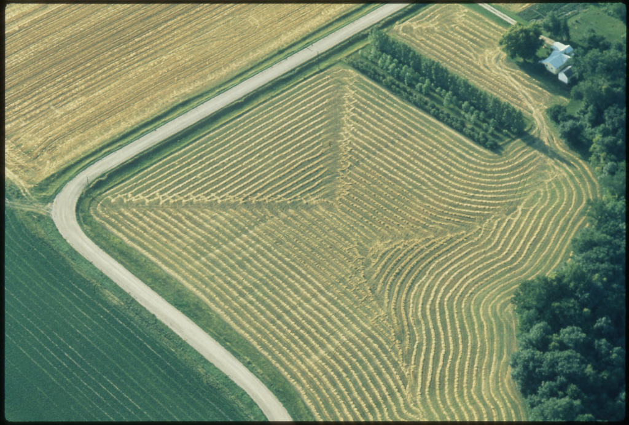

*Feed Supply Chain Transparency*

*Integrating Land Use into Climate Planning*

*Diversification Away from Feed Crops*

A large share of Minnesota’s cropland is linked to livestock feed, but this relationship is not directly observable in currently available datasets. Crop production, feed processing, and livestock operations are reported separately at present, making it difficult to trace how land use translates into feed demand across regions. Given the scale of livestock production, particularly 8.9 million hogs and pigs, there is a strong case for improving visibility into feed sourcing. Targeted disclosure requirements or reporting frameworks for large livestock operations and processors could help identify where feed inputs originate and how they relate to land use within Minnesota.

Current climate planning frameworks may account for emissions from livestock and crop production, but do not explicitly incorporate how land allocation itself shapes emissions outcomes. Land use considerations can be integrated if we recognize feed crop acreage as part of livestock-related emissions, account for emissions associated with fertilizer use and crop production linked to feed and consider alternative land-use scenarios in long-term climate planning (COCs).

Minnesota’s cropping system is highly concentrated in corn and soybeans, which together account for roughly 70% of total cropland. This concentration limits diversification within agricultural land use. Further, a substantial share of cropland is functionally tied to animal feed systems, either directly through forage and silage or indirectly through grain and oilseed crops (as noted previously, almost 61%). Policies that support incremental diversification of cropland, such as incentives for alternative crops, crop rotations, or food-oriented production, could reduce over-reliance on feed-linked systems and improve resilience to market and climate fluctuations in the long-term.